# DS400: Assignment IV (Python)

##### Mohamed Elsherif (Student ID: 6378374)

##### January 19, 2025

```python
# Required Libraries setup
import requests
import pandas as pd
import numpy as np
from datetime import datetime
import matplotlib.pyplot as plt
import seaborn as sns
from lxml import html
```

## Open-Meteo APIs

1. Use the Open-Meteo geocoding API to retrieve the coordinates for Tübingen.

```python
# Open-Meteo Geocoding API URL
url = "https://geocoding-api.open-meteo.com/v1/search"

# Parameters for the request
params = {
    'name': 'Tübingen',
    'language': 'en',
    'count': 1
}

# Send request
response = requests.get(url, params=params)

# Extract coordinates directly from response
data = response.json()

coordinates = data['results'][0]
latitude = coordinates['latitude']
longitude = coordinates['longitude']
```

2. Print the coordinates (longitude and latitude).

```python
print(f"Coordinates for Tübingen: Latitude = {latitude}, Longitude = {longitude}")
```

```
Coordinates for Tübingen: Latitude = 48.52266, Longitude = 9.05222
```

3. Retrieve the historic weather data for Tübingen from 1940 to 2024 and store the data in a data frame.

```python
# Open-Meteo Historical Weather API
url = "https://archive-api.open-meteo.com/v1/era5"

# List to store the weather data for each year
weather_data = []

# Date range from 1940 to 2024
start_year = 1940
end_year = 2024

# Loop through each year
for year in range(start_year, end_year + 1):
    # Request parameters for the API
    params = {
        'latitude': latitude,
        'longitude': longitude,
        'start_date': f'{year}-01-01',
        'end_date': f'{year}-12-31',
        'hourly': 'temperature_2m',
        'temperature_unit': 'celsius',
        'timezone': 'Europe/Berlin'
    }

    # Send request to API
    response = requests.get(url, params=params)

    response.status_code == 200
    data = response.json()
    # Extract temperature data for the year
    if 'hourly' in data:
        temperatures = data['hourly']['temperature_2m']
        dates = data['hourly']['time']

        # Create a DataFrame for temperatures
        df = pd.DataFrame({'Date': pd.to_datetime(dates),'Temperature': temperatures})

        # Add the year to the DataFrame
        df['Year'] = df['Date'].dt.year

        # Append the DataFrame for this year to the list
        weather_data.append(df)

# Combine all the DataFrames for the years 1940-2024 into one DataFrame
all_data = pd.concat(weather_data, ignore_index=True)
```

4. Compute the yearly average temperatures. Print the first five rows of the data frame.

```python
# Compute the yearly average temperature
yearly_avg_temperatures = all_data.groupby('Year')['Temperature'].mean().reset_index()

# Print first five rows
print(yearly_avg_temperatures.head())
```

```
   Year  Temperature
0  1940     7.428783
1  1941     7.851986
2  1942     8.314703
3  1943     9.812831
4  1944     8.860041
```

5. Create a “temperature anomaly” plot. It should look as close as possible like the one shown below.

The temperature anomaly is the difference between the yearly average temperature and the average temperature over a specific period. Here, we choose the period of 1991–2020 (similar to the one from Our World in Data). The plot should show the temperature anomalies for Tübingen from 1940 to 2024 (with the average temperature of 1991–2020 as the reference).

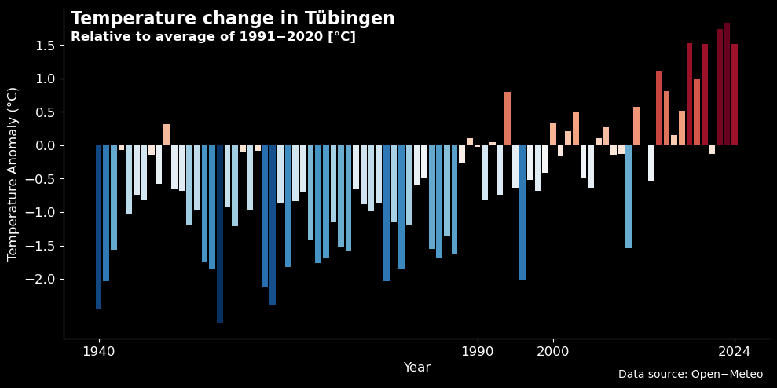

```python
# Calculate the reference period average
reference_period = yearly_avg_temperatures[(yearly_avg_temperatures['Year'] >= 1991) & (yearly_avg_temperatures['Year'] <= 2020)]
reference_avg_temp = reference_period['Temperature'].mean()

# Calculate the temperature anomaly
yearly_avg_temperatures['Temperature Anomaly'] = yearly_avg_temperatures['Temperature'] - reference_avg_temp

# Plot the temperature anomaly
plt.figure(figsize=(10, 5), facecolor='black')  # Set the figure background to black

# Normalize the temperature anomaly values to be between 0 and 1 for both positive and negative values
norm = plt.Normalize(vmin=min(yearly_avg_temperatures['Temperature Anomaly']), vmax=max(yearly_avg_temperatures['Temperature Anomaly']))

# Apply the 'RdBu_r' colormap to the temperature anomalies
colors = plt.cm.RdBu_r(norm(yearly_avg_temperatures['Temperature Anomaly']))

# Plot bar chart with corresponding colors
plt.bar(yearly_avg_temperatures['Year'], yearly_avg_temperatures['Temperature Anomaly'], color=colors)

# Set the title and subtitle in the top-left corner
plt.text(0.01, 0.95, 'Temperature change in Tübingen', transform=plt.gca().transAxes, fontsize=16, fontweight='bold', color='white')
plt.text(0.01, 0.90, 'Relative to average of 1991−2020 [°C]', transform=plt.gca().transAxes, fontsize=12, fontweight='bold', color='white')

# Set plot background color to black
plt.gca().set_facecolor('black')

# Set the x-axis tick labels
plt.xticks([1940, 1990, 2000, 2024], fontsize=12, color='white')

plt.xlabel('Year', fontsize=12, color='white')
plt.ylabel('Temperature Anomaly (°C)', fontsize=12, color='white')

# Set "Data source" text at the bottom-right
plt.text(0.99, -0.12, 'Data source: Open−Meteo', transform=plt.gca().transAxes, fontsize=10, color='white', ha='right')

# Set the color of the axes and ticks to white
plt.tick_params(axis='x', colors='white')
plt.tick_params(axis='y', colors='white')
plt.gca().spines['left'].set_color('white')
plt.gca().spines['bottom'].set_color('white')

# Set y-axis ticks labels
plt.yticks(np.arange(-2, 2.1, 0.5)[:-1], fontsize=12, color='white')

plt.grid(False)
plt.tight_layout()
plt.show()
```

## Web Scraping

6. Scrape the repository name, the repository URL, the repository’s short description, the number of stars,

and the last updated date for the first 20 repositories on the GitHub machine-learning topic page. Put the scraped data into a data frame. Print the entire data frame.

```python
# GitHub page URL
URL = "https://github.com/topics/machine-learning"

# Fetch page content
response = requests.get(URL)

# Parse the page content
tree = html.fromstring(response.content)

# XPath repository names
repo_names = tree.xpath('//*[contains(concat(" ", @class, " "), " wb-break-word ")]')

# XPath repository descriptions
repo_descriptions = tree.xpath('//*[contains(concat(" ", @class, " "), " color-fg-muted ") and contains(concat(" ", @class, " "), " mb-0 ")]')

# XPath last updated dates
last_updated = tree.xpath('//*[contains(concat(" ", @class, " "), " color-fg-muted ")]//*[contains(concat(" ", @class, " "), " no-wrap ")]')

# XPath for stars numbers
stars = tree.xpath('(//*[contains(concat(" ", @class, " "), " btn ")]//span[not(contains(text(), "Star")) and not(contains(text(), "All")) and not(contains(text(), "Most"))])[position() <= 21]')

# Clean the star count text
stars_text = [star.text_content().strip().split(' ')[0] for star in stars]

# Compile data as dataframe
repositories = []
for name, desc, updated, star in zip(repo_names, repo_descriptions, last_updated, stars_text):
    repositories.append({
        "Repository Name": name.text_content().strip(),
        "Repository URL": f"https://github.com{name.get('href')}",
        "Description": desc.text_content().strip(),
        "Last Updated": updated.text_content().strip(),
        "Stars": star
    })
df = pd.DataFrame(repositories)
df
```

|  | Repository Name | Repository URL | Description | Last Updated | Stars |
| --- | --- | --- | --- | --- | --- |
| 0 | tensorflow | https://github.com/tensorflow/tensorflow | An Open Source Machine Learning Framework for ... | Jan 20, 2025 | 187k |
| 1 | transformers | https://github.com/huggingface/transformers | 🤗 Transformers: State-of-the-art Machine Learn... | Jan 19, 2025 | 138k |
| 2 | pytorch | https://github.com/pytorch/pytorch | Tensors and Dynamic neural networks in Python ... | Jan 20, 2025 | 86k |
| 3 | netdata | https://github.com/netdata/netdata | Architected for speed. Automated for easy. Mon... | Jan 20, 2025 | 73k |
| 4 | ML-For-Beginners | https://github.com/microsoft/ML-For-Beginners | 12 weeks, 26 lessons, 52 quizzes, classic Mach... | Jan 1, 2025 | 70.7k |
| 5 | cs-video-courses | https://github.com/Developer-Y/cs-video-courses | List of Computer Science courses with video le... | Sep 13, 2024 | 67.9k |
| 6 | d2l-zh | https://github.com/d2l-ai/d2l-zh | 《动手学深度学习》：面向中文读者、能运行、可讨论。中英文版被70多个国家的500多所大学用于教学。 | Jul 30, 2024 | 65.2k |
| 7 | tesseract | https://github.com/tesseract-ocr/tesseract | Tesseract Open Source OCR Engine (main reposit... | Jan 17, 2025 | 63.9k |
| 8 | keras | https://github.com/keras-team/keras | Deep Learning for humans | Jan 18, 2025 | 62.4k |
| 9 | scikit-learn | https://github.com/scikit-learn/scikit-learn | scikit-learn: machine learning in Python | Jan 20, 2025 | 60.8k |
| 10 | awesome-scalability | https://github.com/binhnguyennus/awesome-scala... | The Patterns of Scalable, Reliable, and Perfor... | Dec 14, 2024 | 60k |
| 11 | annotated_deep_learning_paper_implementations | https://github.com/labmlai/annotated_deep_lear... | 🧑‍🏫 60+ Implementations/tutorials of deep lear... | Aug 24, 2024 | 58.1k |
| 12 | face_recognition | https://github.com/ageitgey/face_recognition | The world's simplest facial recognition api fo... | Aug 21, 2024 | 54k |
| 13 | faceswap | https://github.com/deepfakes/faceswap | Deepfakes Software For All | Nov 19, 2024 | 52.9k |
| 14 | yolov5 | https://github.com/ultralytics/yolov5 | YOLOv5 🚀 in PyTorch > ONNX > CoreML > TFLite | Jan 15, 2025 | 52k |
| 15 | julia | https://github.com/JuliaLang/julia | The Julia Programming Language | Jan 20, 2025 | 46.2k |
| 16 | 100-Days-Of-ML-Code | https://github.com/Avik-Jain/100-Days-Of-ML-Code | 100 Days of ML Coding | Dec 29, 2023 | 46.1k |
| 17 | TensorFlow-Examples | https://github.com/aymericdamien/TensorFlow-Ex... | TensorFlow Tutorial and Examples for Beginners... | Jul 26, 2024 | 43.5k |
| 18 | llm-course | https://github.com/mlabonne/llm-course | Course to get into Large Language Models (LLMs... | Jan 18, 2025 | 42.8k |
| 19 | airflow | https://github.com/apache/airflow | Apache Airflow - A platform to programmaticall... | Jan 20, 2025 | 38.4k |

7. Visualize the popularity of these repositories by creating a bar plot showing the number of stars of the

top 10 repositories. The plot should look similar to the one shown below.

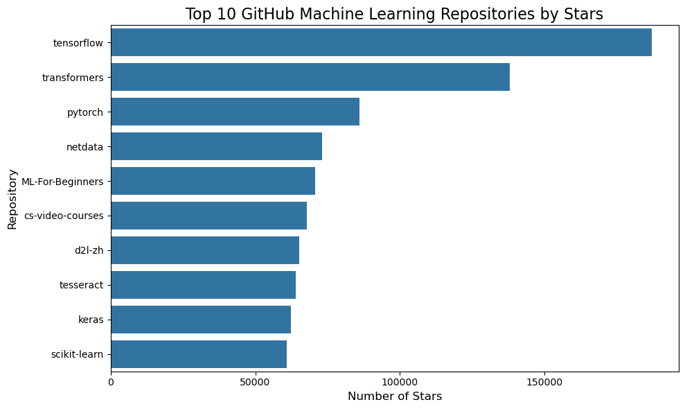

```python
# Ensure 'Stars' are treated as numeric values
def numberize_stars(star_value):
    if 'k' in star_value:
        return float(star_value.replace('k', '').strip()) * 1000
    elif 'M' in star_value:
        return float(star_value.replace('M', '').strip()) * 1000000
    else:
        return float(star_value)

# Numberize the 'Stars' column
df['Stars Numeric'] = df['Stars'].apply(numberize_stars)

# Sort repositories by stars and get top 10
top_10_repositories = df.nlargest(10, 'Stars Numeric')

# Bar plot for top 10 repositories
plt.figure(figsize=(10, 6))
sns.barplot(x='Stars Numeric', y='Repository Name', data=top_10_repositories)
plt.title('Top 10 GitHub Machine Learning Repositories by Stars', fontsize=16)
plt.xlabel('Number of Stars', fontsize=12)

# Set the x-ticks at every 50,000 interval excluding 200,000
plt.xticks(ticks=range(0, int(top_10_repositories['Stars Numeric'].max()) + 50000, 50000)[:-1]
           if 200000 in range(0, int(top_10_repositories['Stars Numeric'].max()) + 50000, 50000) else range(0, int(top_10_repositories['Stars Numeric'].max()) + 50000, 50000))

plt.ylabel('Repository', fontsize=12)
plt.tight_layout()
plt.show()
```